# Regression Example - Causality X

Elizabeth Frank O’Neill

Fall 2024

## All About Regression

### Simple Regression Example

Here we will start by defining X and Y as random variables. X has mean of 50 and standard deviation of 10. Y is correlated with X but has added “noise” of a random variable with mean 0 and a standard deviation of 15.

x <- rnorm(100, mean = 50, sd = 10)

y <- 4*x + rnorm(100, mean = 00, sd = 15)

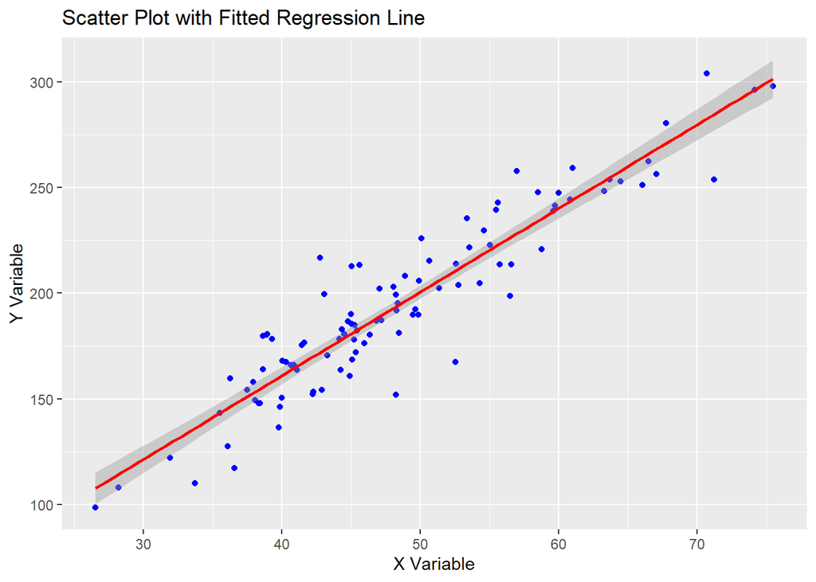

You can see the plot of X and Y, and the fitted regression line in the plot above.

### The Basics of Multiple Regression

#### Multiple Linear Regression Notation and Forumlas

This lesson was adapted from a lesson taught under Prof Juana Sanchez for Stats 102B. Linear Regression simply looks at the relationship of a predictor and response variable. In multiple regression we still have one response variable but multiple predictor variables.

The general equation for multiple regression takes the form:

$\mathbf{y}=\mathbf{X\beta}+\mathbf{e}$

where $\mathbf{y}$ is our response variable, $\mathbf{\beta}$ are the coefficients and {$\mathbf{X_1,....X_n}$} are the predictor variables.

$\\$

For a standard linear model, the following assumptions are then made: $E(\mathbf{e})=0$

$Var - Cov(\mathbf{e}) = E(\mathbf{ee}^t)=\sigma^2\mathbf{I}$

We can also then define our residuals $\mathbf{e}$ as follows: $\mathbf{e}=\mathbf{y}-\mathbf{X\beta}$

$\\$ $\\$

Using the principle of least squares, we can estimate the $\mathbf{\beta}$ parameter values by minimizing

$S=\mathbf{y'y}-2\mathbf{\beta'X'y}+\mathbf{\beta'X'X\beta}$

How would we use least squares to solve this? Optimization!

$\\$

#### Optimization

Optimization process

1. Take the derivative of $S$ with respect to $\mathbf{\beta}$
2. Set the derivative equal to 0.
3. Solve for $\hat{\beta}$

$\\$ Now, we need to estimate the constant variance of $e_i$, $\hat{\sigma^2}$. This will be the same as the variance of $y_i$ where $i=1,....,n$

This is solved the same way as when we are looking at one variable, but using matrix notation to account for the multiple variables here. We take the estimated sum of squared residuals and divide by the degrees of freedom.

That is $\hat{\sigma^2}=\frac{\sum{(y_i-\hat{y_i})^2}}{n-p}$ Where $n$ is the sample size and $p$ is the number of betas including the intercept, $\beta_0$.

$\\$ The residual standard error is then $\hat{\sigma}=\sqrt{\frac{\mathbf{e'e}}{n-p}}$

$\\$ We can also see the $SS_{Res}$ in matrix form as follows: $SS_{Res}=\mathbf{e'e}$ which when expanded, using $\mathbf{e}=\mathbf{y}-\mathbf{X\beta}$ and simplifying gives $\mathbf{y'y-\hat{\beta'}X'y}$

$\\$ Then, the Mean Squared Residual is given by $MS_{Res}=\frac{SS_{Res}}{n-p}$

$\\$ $\\$

#### Properties of the estimators

There are also some important properties of the estimators to recall. We can prove mathematically, that the least squares estimator for our $\mathbf{\beta}$ model parameter values, is unbiased.

We can also define the Variance-Covariance matrix of the $\hat{\mathbf{\beta}}$ as $Cov(\hat{\mathbf{\beta}})=\hat{\sigma^2}(\mathbf{X'X})^{-1}$.

$\\$ It is worth noting that the correlation matrix of the coefficients will be the same dimensions as the var-cov matrix, but the entries of the matrix are divided by the product of the std dev of each of the coefficients.

$\\$ With the assumption of normality of error terms, $\hat{\mathbf{\beta}}$ is the MLE of $\mathbf{\beta}$, and therefore achieves the CRLB which means it has minimum variance. Without the assumption of normality, $\hat{\mathbf{\beta}}$ has the lowest variance among all unbiased estimators of $\hat{\mathbf{\beta}}$.[Gauss Markov Theorem]

$\\$ $\\$

### Housing Analysis Example

#### Housing data as an example of multiple regression

Let’s run an example using housing data.

```r
## Read in DataSet
houses = read.delim("http://www.stat.ucla.edu/~jsanchez/data/montproperty.txt", header=TRUE, sep="\t")

head(houses)
```

```
##      y     x1 x2    x3    x4 x5 x6 x7 x8 x9
## 1 25.9 4.9176  1 3.472 0.998  1  7  4 42  0
## 2 29.5 5.0208  1 3.531 1.500  2  7  4 62  0
## 3 27.9 4.5429  1 2.275 1.175  1  6  3 40  0
## 4 25.9 4.5573  1 4.050 1.232  1  6  3 54  0
## 5 29.9 5.0597  1 4.455 1.121  1  6  3 42  0
## 6 29.9 3.8910  1 4.455 0.988  1  6  3 56  0
```

Our variables are defined as $\\$  
Y= sale price of house / 1000 $\\$ X1= Taxes(local,school,county)/1000 $\\$  
X2= number of baths $\\$  
X3= lot size (sqft x 1000) $\\$  
X4= Living Space (sqft x 1000) $\\$  
X5= number of garage stalls $\\$ X6= number of rooms $\\$ X7= number of bedrooms $\\$  
X8= age of the home (years) $\\$  
X9= number of fireplaces $\\$

```r
model1<-lm(y~x1+x2+x3+x4+x5+x6+x7+x8+x9, data=houses)
model1
```

```
##
## Call:
## lm(formula = y ~ x1 + x2 + x3 + x4 + x5 + x6 + x7 + x8 + x9,
##     data = houses)
##
## Coefficients:
## (Intercept)           x1           x2           x3           x4           x5
##    14.92765      1.92472      7.00053      0.14918      2.72281      2.00668
##          x6           x7           x8           x9
##    -0.41012     -1.40324     -0.03715      1.55945
```

```r
anova(model1)
```

```
## Analysis of Variance Table
##
## Response: y
##           Df Sum Sq Mean Sq F value    Pr(>F)
## x1         1 636.16  636.16 73.1525 6.238e-07 ***
## x2         1  29.18   29.18  3.3551   0.08836 .
## x3         1   4.71    4.71  0.5416   0.47391
## x4         1   0.03    0.03  0.0032   0.95537
## x5         1   8.78    8.78  1.0091   0.33216
## x6         1  13.03   13.03  1.4982   0.24115
## x7         1   9.14    9.14  1.0515   0.32254
## x8         1   0.64    0.64  0.0741   0.78943
## x9         1   5.63    5.63  0.6478   0.43435
## Residuals 14 121.75    8.70
## ---
## Signif. codes:  0 '***' 0.001 '**' 0.01 '*' 0.05 '.' 0.1 ' ' 1
```

What do you notice about these results?

$\\$ $\\$ $\\$

```r
summary(model1,cor=TRUE)
```

```
##
## Call:
## lm(formula = y ~ x1 + x2 + x3 + x4 + x5 + x6 + x7 + x8 + x9,
##     data = houses)
##
## Residuals:
##    Min     1Q Median     3Q    Max
## -3.720 -1.956 -0.045  1.627  4.253
##
## Coefficients:
##             Estimate Std. Error t value Pr(>|t|)
## (Intercept) 14.92765    5.91285   2.525   0.0243 *
## x1           1.92472    1.02990   1.869   0.0827 .
## x2           7.00053    4.30037   1.628   0.1258
## x3           0.14918    0.49039   0.304   0.7654
## x4           2.72281    4.35955   0.625   0.5423
## x5           2.00668    1.37351   1.461   0.1661
## x6          -0.41012    2.37854  -0.172   0.8656
## x7          -1.40324    3.39554  -0.413   0.6857
## x8          -0.03715    0.06672  -0.557   0.5865
## x9           1.55945    1.93750   0.805   0.4343
## ---
## Signif. codes:  0 '***' 0.001 '**' 0.01 '*' 0.05 '.' 0.1 ' ' 1
##
## Residual standard error: 2.949 on 14 degrees of freedom
## Multiple R-squared:  0.8531, Adjusted R-squared:  0.7587
## F-statistic: 9.037 on 9 and 14 DF,  p-value: 0.000185
##
## Correlation of Coefficients:
##    (Intercept) x1    x2    x3    x4    x5    x6    x7    x8
## x1  0.23
## x2 -0.32       -0.44
## x3 -0.20       -0.37  0.24
## x4  0.06       -0.18 -0.42 -0.29
## x5  0.07       -0.32  0.23  0.16  0.08
## x6 -0.65       -0.57  0.29  0.08 -0.05  0.05
## x7  0.46        0.45 -0.29 -0.05 -0.16 -0.29 -0.84
## x8 -0.31        0.36 -0.04  0.14 -0.02  0.08 -0.02 -0.26
## x9  0.46        0.24 -0.31 -0.35  0.12 -0.18 -0.48  0.54 -0.38
```

$\\$

#### Making Statistical Inference

#### Checking significance of the model

We have run the model and produced a regression output, but in order to make any stastical inference about the elements produced in $\mathbf{\beta}$ there are additional steps that should be taken.

First, let’s check if the model is significant using the F test. Here, we could use hypothesis testing (covered in stats 100B, not necessary for this course but perhaps useful).

$\\$ We will define our $H_0$ and $H_a$ for determining if there is a linear relationship between y and any of the independent vars $x_1, x_2,..., x_k$ with $H_0: \beta_1=\beta_2=....=\beta_k=0$ $H_a:\beta_j \neq 0$ for at least 1 $j$

$\\$ Rejection of $H_0$, our null hypothesis gives that at least one of our x variables affects the dependent variable y.

$\\$ The F statistic for this test is then defined as $F=\frac{\frac{\sum{(\hat{y_i}-\bar{y})^2}}{k}}{\frac{\sum{(y_i-\hat{y_i})^2}}{n-p}}=\frac{\frac{SS_R}{k}}{\frac{SS_{Res}}{n-p}}=\frac{MS_R}{MS_{Res}}$

In this case for our housing example, we get $F_{9, 14}=9.037$

The p-value for this F would be 0.000185, so we can conclude at leaset one of the independent variables is significant. $\\$

But how do we check which variable(s)?

$\\$

#### Checking individual variable significance

We can use t-tests for each individual variable in order to check significance.

We will simply set up our test as follows: for $j=0,1,...,p$

$H_0: \beta_j=0$

$H_a: \beta_j\neq 0$

If the null cannot be rejected, it suggests we can remove it from the model.

The t-test is then set up and solved using $t_{n-p}=\frac{\hat{\beta_j}-0}{se(\hat{\beta_j})}=\frac{\hat{\beta_j}-0}{\sqrt{Cov(\hat{\beta_j},\hat{\beta_j})}}$

In this case, we will find that the intercept, $\hat{\beta_0}$ is significant but none of the other $\beta_j$’s are significantly different from 0.

$\\$

#### Let’s discuss

Does that result make sense?

$\\$ $\\$ $\\$ What is happening here in this case? $\\$ $\\$ $\\$

This housing example is an instance of Multicollinearity.

By definition, multicollinearity is when “one predictor variable in a multiple regression model can be linearly predicted from the others with a substantial degree of accuracy.”

Essentially, this means, if the predictors are very correlated and this then skews the results and will cause problems in our regression analysis.

When multicollinearity is a problem, it is advised to use dimension reduction techniques such as PCA.